# Korpusanalyse eines Selbsthilfeforums von Inhaftierung betroffener Angehöriger

# 8. Überblick über die Topics und Wörter

|  | X1 | X2 | X3 | X4 | X5 | X6 | X7 | X8 | X9 | X10 | X11 | X12 | X13 | X14 | X15 | X16 | X17 | X18 | X19 | X20 | X21 | X22 | X23 | X24 | X25 | X26 | X27 | X28 | X29 | … |
| --- | --- | --- | --- | --- | --- | --- | --- | --- | --- | --- | --- | --- | --- | --- | --- | --- | --- | --- | --- | --- | --- | --- | --- | --- | --- | --- | --- | --- | --- | --- |
| 1 | telefon | euro | fenster | anstalt | nich | löschen | maßnahme | automat | medikament | punkt | bewährungswiderruf | paket | trennscheibe | ladung | überfordern | gesetzlich | überweisen | stellungnahme | rauchen | schreiten | jährig | ergebnis | berufung | bilden | abbrechen | erwachsen | zugang | verteidiger | mord | … |
| 2 | zeitung | zahlen | sollen | mann | sowas | forum | stgb | stunde | arzt | frage | monat | brief | besuchen | termin | kind | gefangene | geld | antrag | fahren | droge | polizei | seite | anwalt | wort | therapie | bauen | zeit | gericht | fall | … |
| 3 | anruf | bezahlen | rahmen | arbeit | denken | mitglied | voraussetzung | minute | psychisch | weiß | strafen | dürfen | beamte | melden | mutter | bayer | konto | halbstrafe | auto | kaum | jährige | internet | urteilen | solch | btmg | betreffen | draußen | angeklagte | deutschland | … |
| 4 | berlin | wohnung | stellen | kochen | mara | beitrag | freiheitsstrafe | besuchen | patient | eigentlich | bewährung | schick | besuch | weis | eltern | regeln | firma | anhörung | zuhause | keinerlei | mädchen | bitte | verhandlung | täter | einrichtung | raupe | drinnen | richter | angehörige | … |
| 5 | dame | kosten | welch | märz | irgendwas | user | widerrufen | dürfen | kranken | beantworten | anrechnen | erlauben | nett | genau | vater | zusätzlich | einkauf | entlassung | zigarette | umstand | polizist | bitten | revision | jedoch | sucht | respekt | vergehen | verfahren | diskussion | … |
| 6 | september | staat | verfügung | tatsache | jedenfalls | thema | erfolgen | telefonieren | mensch | freund | jahr | briefmarken | besucher | zeugen | tochter | zum beispiel | anrufen | richter | gibts | nachdenken | töten | beim | staatsanwaltschaft | opfern | klinik | manch | jed_tagen | verhandlung | schuld | … |
| 7 | anrufen | privat | kollege | arbeiten | erzählen | online | entscheidung | tabak | straffällig | datum | widerrufen | tabak | raum | ablaufen | papa | zuständig | verdienen | ablehnen | gehts | verändern | frau | angeben | staatsanwalt | straftat | jahr | mist | wichtig | zeuge | angelika | … |
| 8 | telefonieren | arbeit | bezüglich | hausen | wirklich | thread | anordnen | mitnehmen | krankenhaus | antwort | verbüßen | mitbringen | freundlich | fragen | mama | folgend | zum beispiel | beschluss | trinken | vergangenheit | jahr_alt | wenden | rechtskräftig | wohl | droge | bestimmen | woche | prozess | liegen | … |
| 9 | verlaufen | heisst | sichern | selber | einfach | bild | behandlung | kaufen | partner | wohnen | strafe | strafhaft | besuchstermin | schreiben | jahr_alt | liebe_grußhardy | arbeiten | 2/3_termin | erwischen | schaffen | online | hoffentlich | einlegen | mensch | patient | lernen | leben | landgericht | täter | … |
| 10 | bereich | folgen | entsprechend | erzählen | gucken | chris | zwei_jahr | kaffee | ruhig | lesen | absitzen | post | papa | brief | jung | möglich | betragen | stellen | verbieten | sinnen | verletzen | chance | richter | handeln | erfolgreich | zeigen | knast | anklage | daran | … |

# 9. Visualisierung der Ergebnisse

## 9.1. Meist diskutieren Topics im Korpus

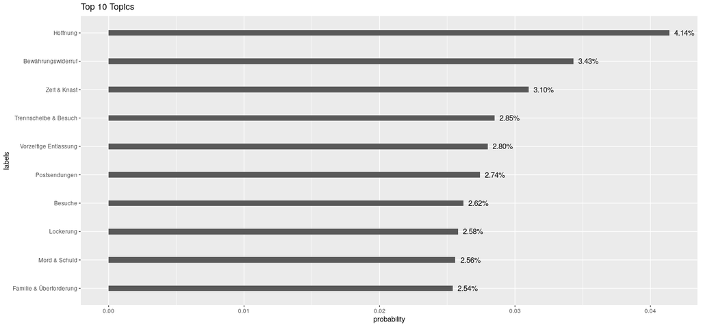

```r
source("functions/top_topics_corpus.R")
top_topics_corpus(stm.theta = model.stm.forum$theta,
                  df.topic.lables = df.topic.labels.forum,
                  topic.del = topic.del.forum,
                  n.top.topics.plot = 10)
```

```r
ggsave("output_vis/top_topics_forum.png", width = 40, height = 15, units = "cm", dpi = 300)
```

## 9.2. Word clouds

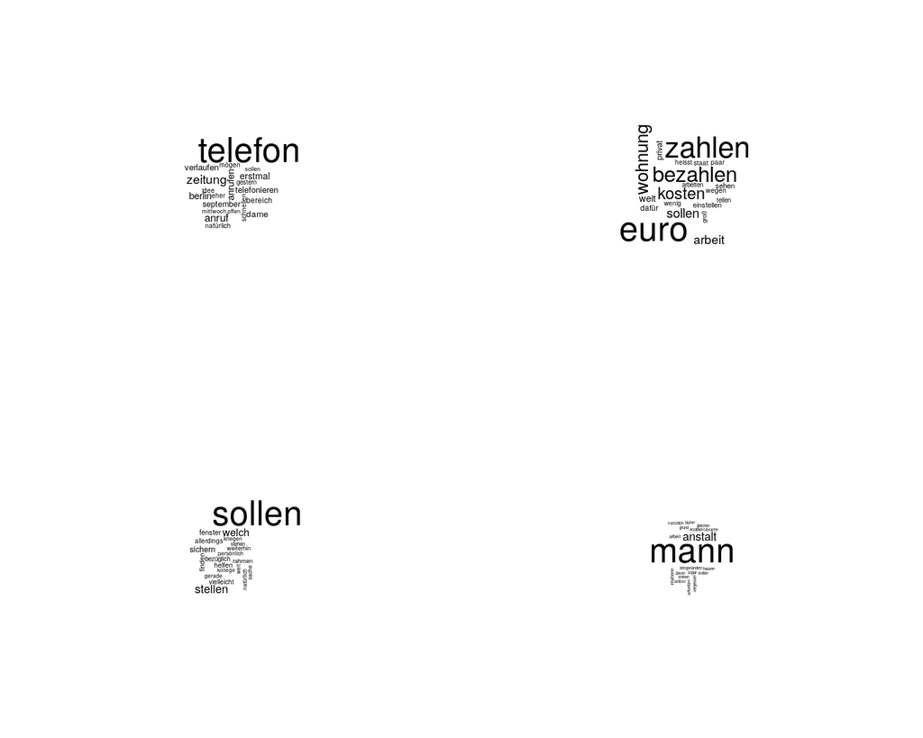

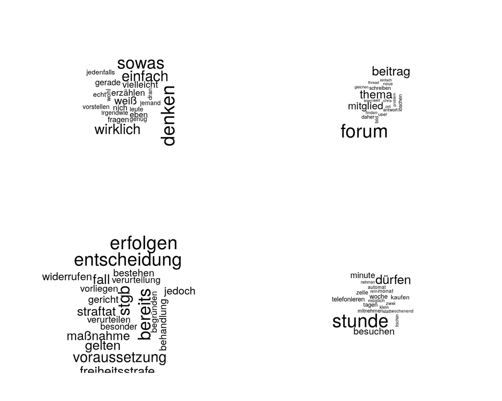

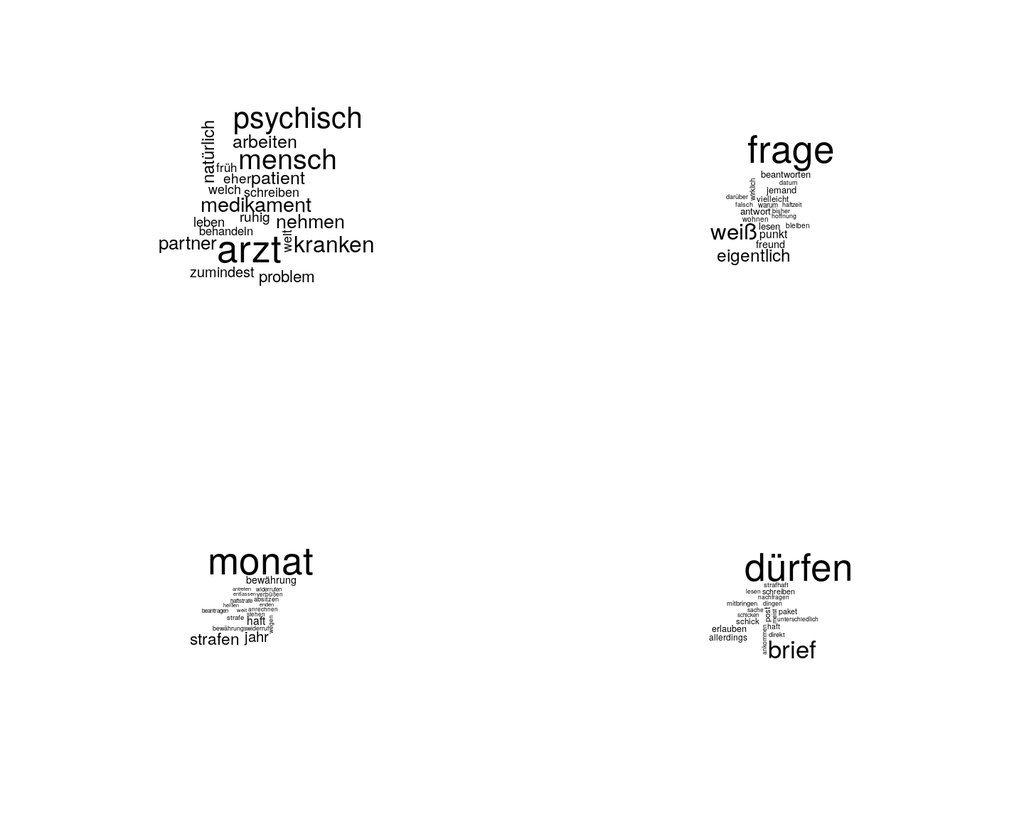

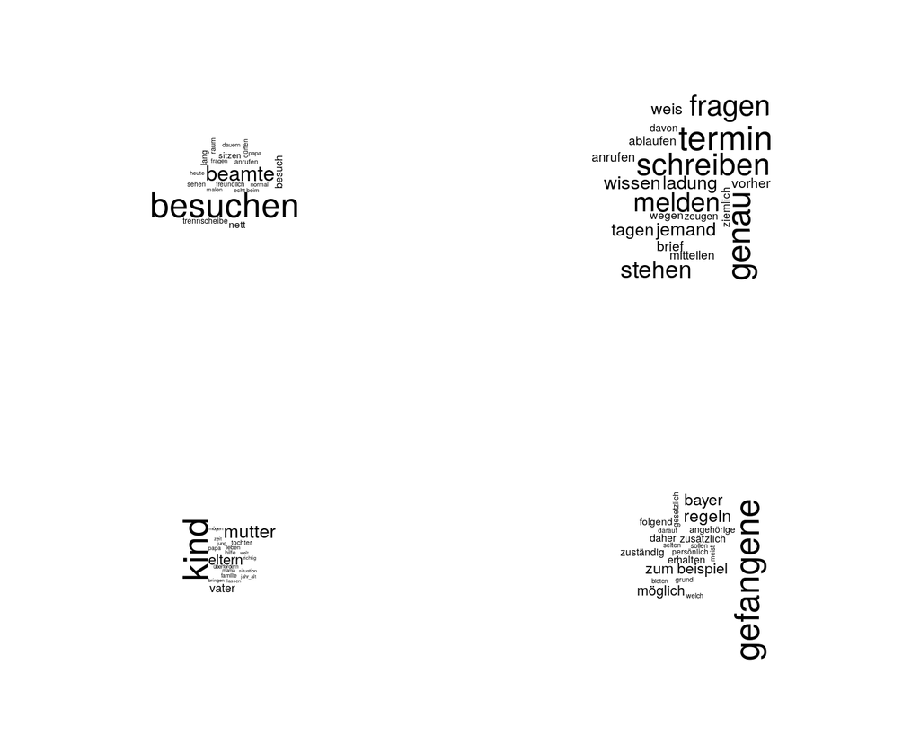

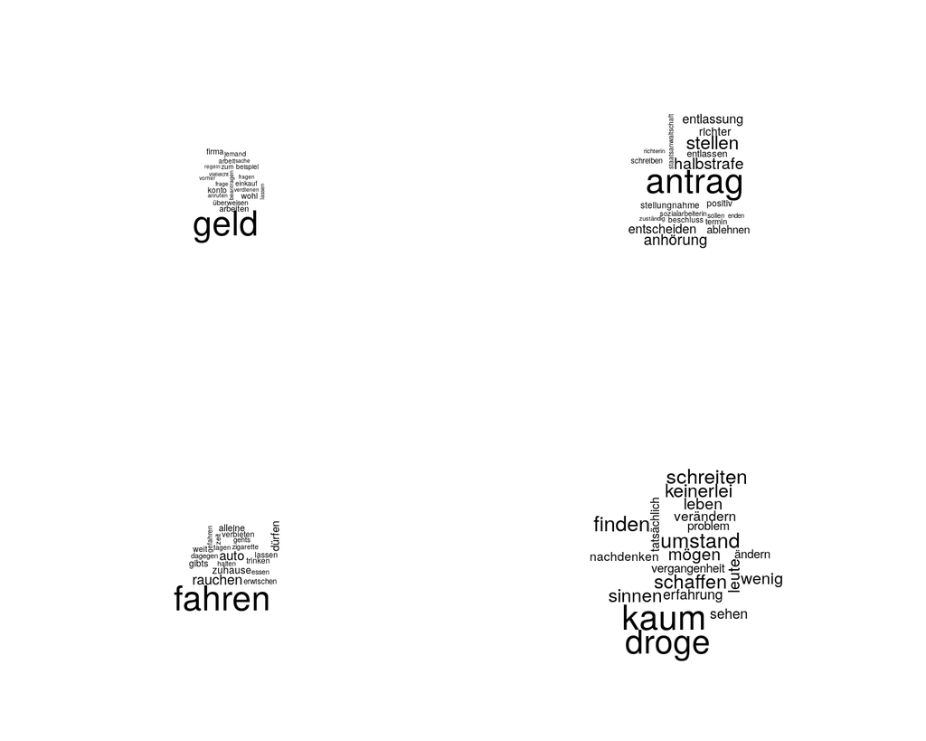

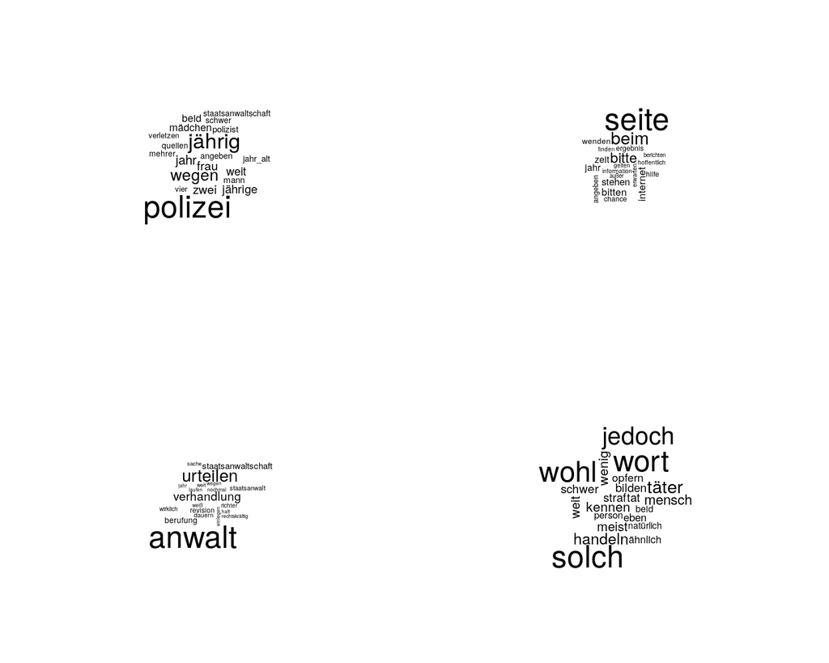

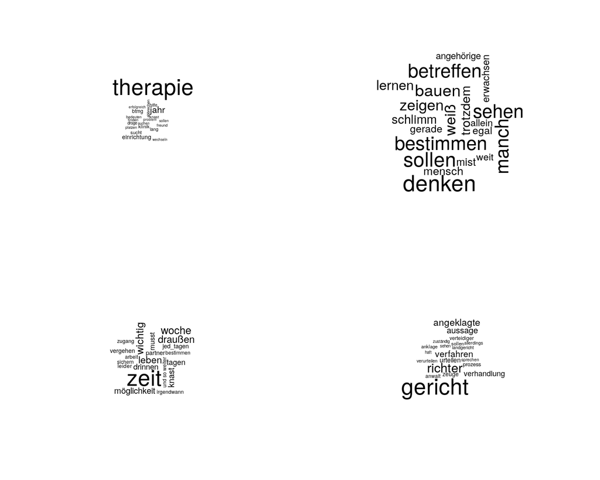

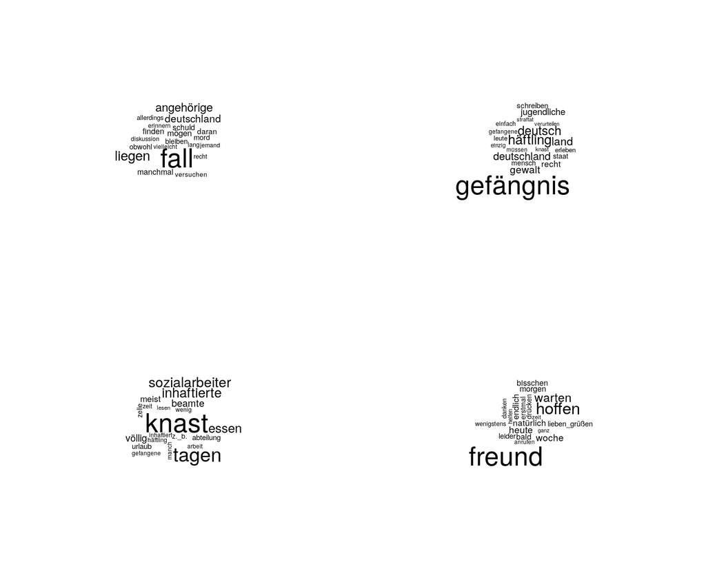

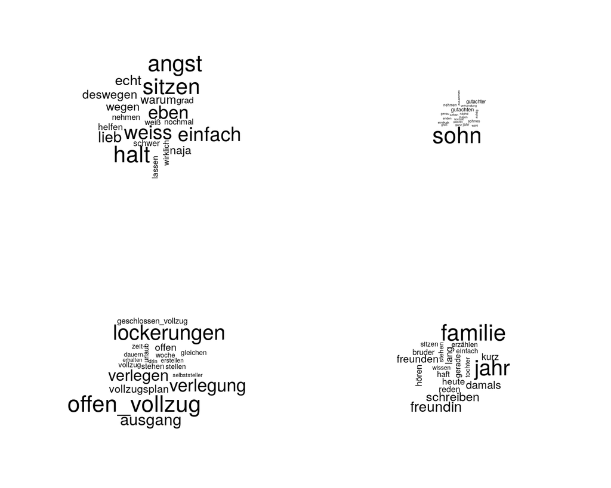

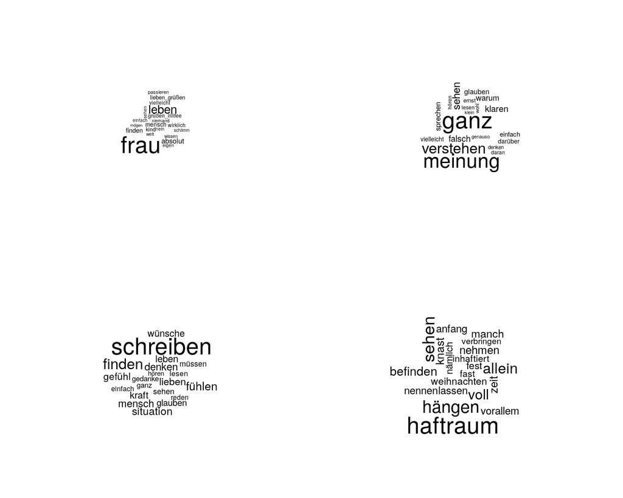

```r
topic.count.forum <- 40
par(mfrow=c(2,2))
for (i in seq_along(sample(1:topic.count.forum, size = topic.count.forum)))
{
  cloud(model.stm.forum, topic = i, scale = c(4,.40),
        max.words = 20, main = paste0("Topic ", df.topic.labels.forum$label[i],
                                      collapse = ", "))
}
```

## 9.3. Topic Korrelationsnetzwerk

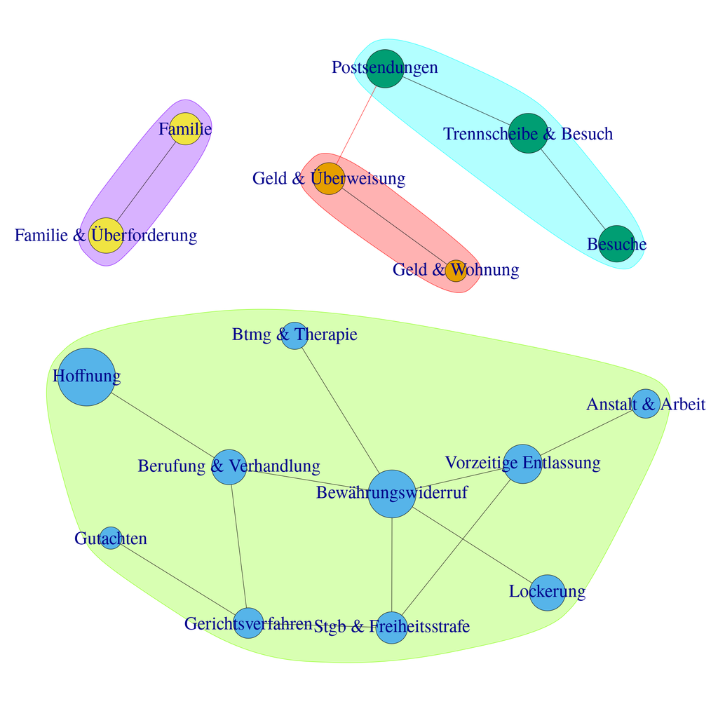

```r
networks.forum <- corr_networks(model.stm = model.stm.forum,
              df.col.topic.labels = df.topic.labels.forum,
              min.correlation = 0.05)
```

```r
ggsave("output_vis/corr_network_forum.png", width = 50, height = 50, units = "cm", dpi = 300)
```

# 10. Erzeugung von Teilkorpora

```r
source("functions/topic_document_dataframe.R")


df.kf3 <- df.kf2 %>% head(2880)



df.Bewaehrungswiederruf <- topic_document_df(model.stm = model.stm.forum,
                                df.text = df.kf3,
                                df.text.col = as.character(df.kf3$Text),
                                topic.id = 11,
                                procent.quantil = 0.99)

write.csv(df.Bewaehrungswiederruf, "output_data/df.Bewaehrungswiederruf.forum.csv")

df.familie_ueberforderung <- topic_document_df(model.stm = model.stm.forum,
                                df.text = df.kf3,
                                df.text.col = as.character(df.kf3$Text),
                                topic.id = 15,
                                procent.quantil = 0.99)

write.csv(df.Bewaehrungswiederruf, "output_data/df.familie_ueberforderung.forum.csv")

df.familie <- topic_document_df(model.stm = model.stm.forum,
                                df.text = df.kf3,
                                df.text.col = as.character(df.kf3$Text),
                                topic.id = 36,
                                procent.quantil = 0.99)

write.csv(df.Bewaehrungswiederruf, "output_data/df.df.familie.csv")

df.emotionaler_beistand <- topic_document_df(model.stm = model.stm.forum,
                                df.text = df.kf3,
                                df.text.col = as.character(df.kf3$Text),
                                topic.id = 32,
                                procent.quantil = 0.99)

write.csv(df.emotionaler_beistand, "output_data/df.emotionaler_beistand.forum.csv")

df.vorzeitige_entlassung <- topic_document_df(model.stm = model.stm.forum,
                                df.text = df.kf3,
                                df.text.col = as.character(df.kf3$Text),
                                topic.id = 18,
                                procent.quantil = 0.99)

write.csv(df.vorzeitige_entlassung, "output_data/df.vorzeitige_entlassung.csv")



df.zeit_knast <- topic_document_df(model.stm = model.stm.forum,
                                df.text = df.kf3,
                                df.text.col = as.character(df.kf3$Text),
                                topic.id = 27,
                                procent.quantil = 0.99)

write.csv(df.zeit_knast, "output_data/df.zeit_knast.csv")


df.trennscheibe <- topic_document_df(model.stm = model.stm.forum,
                                df.text = df.kf3,
                                df.text.col = as.character(df.kf3$Text),
                                topic.id = 13,
                                procent.quantil = 0.99)

write.csv(df.trennscheibe, "output_data/df.trennscheibe.csv")


df.familie_ueberforderung <- topic_document_df(model.stm = model.stm.forum,
                                df.text = df.kf3,
                                df.text.col = as.character(df.kf3$Text),
                                topic.id = 15,
                                procent.quantil = 0.99)

write.csv(df.familie_ueberforderung, "output_data/df.familie_ueberforderung.csv")

df.besuche <- topic_document_df(model.stm = model.stm.forum,
                                df.text = df.kf3,
                                df.text.col = as.character(df.kf3$Text),
                                topic.id = 8,
                                procent.quantil = 0.99)

write.csv(df.besuche, "output_data/besuche.csv")


df.mord_schuld <- topic_document_df(model.stm = model.stm.forum,
                                df.text = df.kf3,
                                df.text.col = as.character(df.kf3$Text),
                                topic.id = 29,
                                procent.quantil = 0.99)

write.csv(df.mord_schuld, "output_data/df.mord_schuld.csv")

dim(df.topic.straf)
```

# 11. Autoren der Studie

Christian Ghanem, Dr., ist Professor an der Technischen Hochschule Nürnberg Georg Simon Ohm. Arbeitsschwerpunkte: Straffälligenhilfe, Professionalisierung und Digitalisierung in der Sozialen Arbeit.

Markus Eckl, MA, ist wissenschaftlicher Mitarbeiter am Lehrstuhl für Digital Humanities an der Universität Passau und Mitarbeiter beim Bezirk Oberpfalz. Arbeitsschwerpunkte: Digitalisierung und Wissenschaft der Sozialen Arbeit, Sozialplanung, quantitative Textanalyse, soziale Netzwerkanalyse.

Jean-Pierre Widerhold, BA, ist Softwareentwickler am Institut für E-Beratung der Technischen Hochschule Nürnberg Georg Simon Ohm. Arbeitsschwerpunkt: Entwicklung von Softwarelösungen für den Sozialen Bereich

Robert Lehmann, Dr., ist Professor an der Technischen Hochschule Nürnberg Georg Simon Ohm und Akademischer Leiter des Instituts für E-Beratung. Arbeitsschwerpunkte: Onlineberatung, Digitalisierung in der Sozialen Arbeit und Wirkungsforschung.